# RNA-Seq tutorial

Nicolas Delhomme, Bastian Schiffthaler

2015-04-12

# 1 Introduction

This tutorial introduces and RNA-Seq differential expression analysis performed using R and Bioconductor(R Development Core Team 2009, al (2004)). As a running example, we use a dataset derived from a study performed in *Populus tremula* (Delhomme et al. 2014). The study looks at the evolutionary theory suggesting that males and females may evolve sexually dimorphic phenotypic and biochemical traits concordant with each sex having different optimal strategies of resource investment to maximise reproductive success and fitness. Such sexual dimorphism should result in sex biased gene expression patterns in non-floral organs for autosomal genes associated with the control and development of such phenotypic traits. Hence, the study among other approaches used gene expression to look for differences between sex. This was achieved by an RNA-Seq differential expression analysis between samples grouped by sex. The samples have been sequenced on an Illumina HiSeq 2000, using TruSeq adapters, through a 101 cycles paired-end protocol, which yielded between 11 million and 34 million reads per sample.

In the following sections, we use the RNA-Seq count data that has been obtained by aligning the pre-processed (adaptor and quality trimmed, rRNA filtered) reads to the *Populus trichocarpa* reference genome. The reason why the reads were aligned to the *Populus trichocarpa* genome is that there is no reference genome for *Populus tremula* and *Populus trichocarpa* is a closely related species (the latter grows in north-western America while the former grows in northern and central Europe).

# 2 Reproducing the DE analysis

## 2.1 Setup - loading the libraries

```r
suppressPackageStartupMessages(library(DESeq))
suppressPackageStartupMessages(library(DESeq2))
suppressPackageStartupMessages(library(easyRNASeq))
suppressPackageStartupMessages(library(RColorBrewer))
suppressPackageStartupMessages(library(vsn))
suppressPackageStartupMessages(library(scatterplot3d))
suppressPackageStartupMessages(library(VennDiagram))
suppressPackageStartupMessages(library(LSD))
source("src/R/plot.multidensity.R")
source("src/R/volcanoPlot.R")
```

## 2.2 Processing the data

### 2.2.1 Reading in the data

First we read the count files produced by HTSeq(Anders, Pyl, and Huber 2014) in a matrix. The DESeq2(Love, Huber, and Anders 2014) package now actually has a function to ease that process: **DESeqDataSetFromHTSeqCount**. Here we just process the samples in parallel using mclapply instead.

```r
res <- mclapply(dir("data/htseq-count",pattern="^[2,3].*_STAR\\.txt",
full.names=TRUE),function(fil){
  read.delim(fil,header=FALSE,stringsAsFactors=FALSE)
},mc.cores=2)
names(res) <- gsub("_.*_STAR\\.txt","",dir("data/htseq-count",pattern="^[2,3].*_STAR\\.txt"))
```

Then we extract the additional information that HTSeq writes at the end of every file detailing the number of reads that were not taken into account while counting summarized by the reason they were rejected.

```r
addInfo <- c("__no_feature","__ambiguous",
             "__too_low_aQual","__not_aligned",
             "__alignment_not_unique")
```

Finally, we extract the reads

```r
sel <- match(addInfo,res[[1]][,1])
count.table <- do.call(cbind,lapply(res,"[",2))[-sel,]
colnames(count.table) <- names(res)
rownames(count.table) <- res[[1]][,1][-sel]
```

### 2.2.2 The HTSeq stat lines

Here we aggregate the information about how many reads aligned together with the information gathered above.

```r
count.stats <- do.call(cbind,lapply(res,"[",2))[sel,]
colnames(count.stats) <- names(res)
rownames(count.stats) <- sub("__","",addInfo)
count.stats <- rbind(count.stats,aligned=colSums(count.table))
count.stats <- count.stats[rowSums(count.stats) > 0,]
```

And convert them as percentages to check them all

```r
apply(count.stats,2,function(co){round(co*100/sum(co))})
```

```
##                      202 207 213.1 221 226.1 229.1 229 235 236 239 244 303
## no_feature             3   3     3   2     3     3   3   3   3   3   3   3
## ambiguous              2   2     2   2     2     2   2   2   2   2   2   2
## alignment_not_unique  13  13    12  13    12    12  12  12  13  14  12  12
## aligned               82  82    83  83    83    83  83  83  82  81  83  83
##                      305.3 309.1 310.3 337.1 349.2
## no_feature               3     3     3     3     3
## ambiguous                2     2     2     2     2
## alignment_not_unique    12    12    13    12    14
## aligned                 83    83    82    83    81
```

As can be seen, an average 82% of the reads aligned uniquely unambiguously to features. About 13% were mapping multiple locations, 2% were on ambigous features (as the data is non strand specific, we have used the “Union” counting scheme) and finally 3% align to no features. This is not at all unexpected given the fact that the alignments were done against the related species P. trichocarpa.

### 2.2.3 Visualizing the HTSeq stats

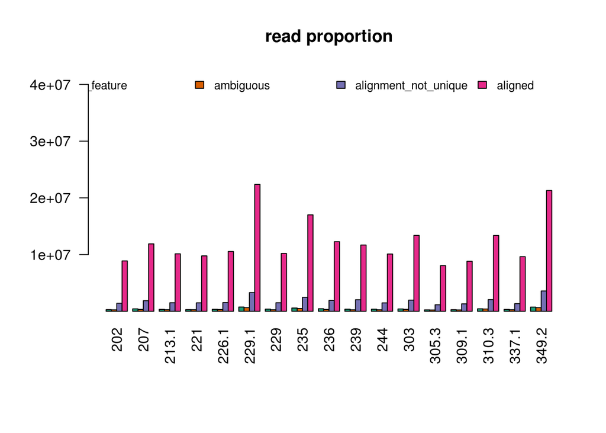

```r
pal=brewer.pal(6,"Dark2")[1:nrow(count.stats)]
mar <- par("mar")
par(mar=c(7.1,5.1,4.1,2.1))
barplot(as.matrix(count.stats),col=pal,beside=TRUE,
        las=2,main="read proportion",
        ylim=range(count.stats) + c(0,2e+7))
legend("top",fill=pal,legend=rownames(count.stats),
       bty="n",cex=0.8,horiz=TRUE)
```

```r
par(mar=mar)
```

Here, one can clearly see the library size effect; the samples 229.1 and 349.2 have been sequenced deeper as these are the parents of a large scale F1 population established for another study. Appart from these, the amount of reads per library seems fairly equally distributed.

### 2.2.4 Deriving more information

It is also important to estimate how much of the reads are not expressed

```r
sel <- rowSums(count.table) == 0
sprintf("%s percent of %s genes are not expressed",
        round(sum(sel) * 100/ nrow(count.table),digits=1)
        ,nrow(count.table))
```

```
## [1] "14.2 percent of 41335 genes are not expressed"
```

So 14.2% of the genes are not expressed out of a total of 41,335 genes

## 2.3 Biological QA

To assess the validity of the replicates, we can look at different metrics.

### 2.3.1 Raw count distribution

We start by looking at the per-gene mean expression, *i.e.* the mean raw count of every gene across samples is calculated and displayed on a log10 scale

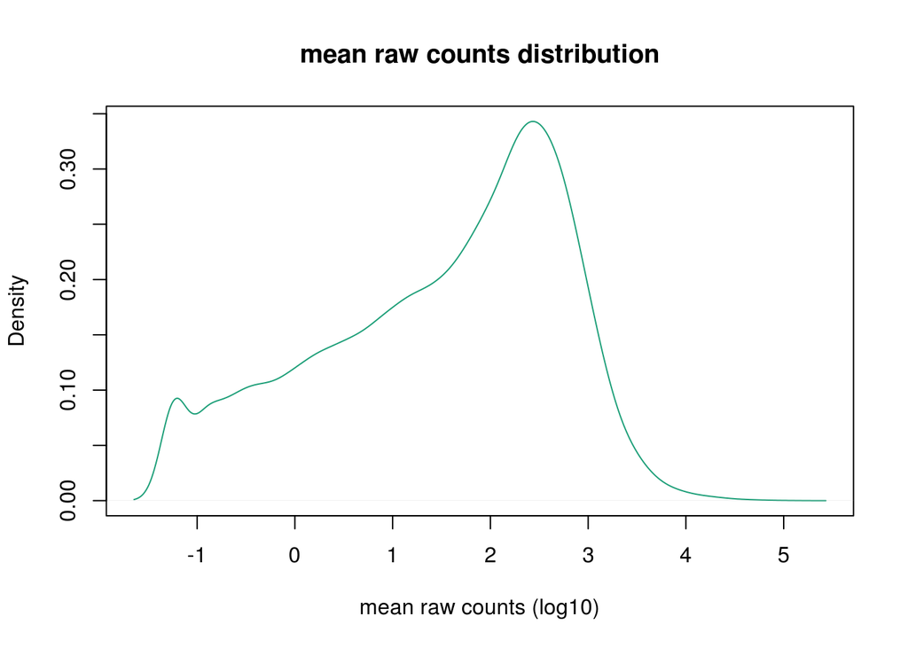

```r
plot(density(log10(rowMeans(count.table))),col=pal[1],
     main="mean raw counts distribution",
     xlab="mean raw counts (log10)")
```

This shows an average of ~300X coverage. Next, the same is done for the individual samples colored by sample type

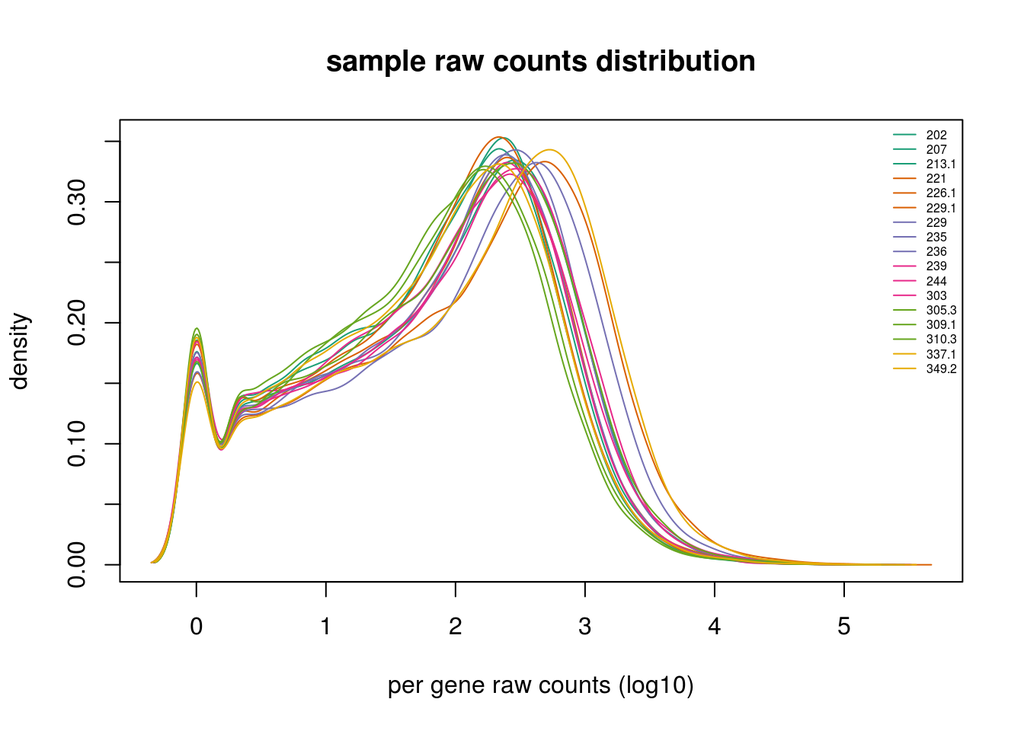

```r
pal=brewer.pal(8,"Dark2")
plot.multidensity(log10(count.table),col=rep(pal,each=3),
                  legend.x="topright",legend.cex=0.5,
                  main="sample raw counts distribution",
                  xlab="per gene raw counts (log10)")
```

As one can see, the samples show a similar trend, although few samples are shifted to the right - those that were sequenced deeper, but this does not affect the global shape of the curve.

## 2.4 Variance stabilisation for better visualisation

For visualization, the data is submitted to a variance stabilization transformation using DESeq2(Love, Huber, and Anders 2014). The dispersion is estimated independently of the sample type We nonetheless define the metadata of importance, *i.e.* every sample sex and year of sampling

```r
samples <- read.csv("~/Git/UPSCb/projects/sex/doc/sex-samples.csv")
conditions <- names(res)
sex <- samples$sex[match(names(res),samples$sample)]
date <- factor(samples$date[match(names(res),samples$sample)])
```

Finally, we create the DESeq2 object, using the sample name as condition (which is hence irrelevant to any comparison)

```r
dds <- DESeqDataSetFromMatrix(
  countData = count.table,
  colData = data.frame(condition=conditions,
                       sex=sex,
                       date=date),
  design = ~ condition)
```

Once this is done, we first check the sequencing library sizes (a.k.a. the size factors) variation.

```r
dds <- estimateSizeFactors(dds)
sizes <- sizeFactors(dds)
names(sizes) <- names(res)
sizes
```

```
##       202       207     213.1       221     226.1     229.1       229
## 0.7834871 1.0658709 0.8751218 0.8124735 0.9130900 1.8946640 0.9291616
##       235       236       239       244       303     305.3     309.1
## 1.5190786 1.0921559 1.0644983 0.9018802 0.9965821 0.6491100 0.7094436
##     310.3     337.1     349.2
## 1.0975623 0.7976525 1.9517753
```

As there is no big variation, we decide to go for a variance stabilisation transformation over a regularised log transformation. Check the DESeq2 [vignette](http://bioconductor.org/packages/release/bioc/vignettes/DESeq2/inst/doc/DESeq2.pdf) for more details about this.

```r
colData(dds)$condition <- factor(colData(dds)$condition,
                                 levels=unique(conditions))
vsd <- varianceStabilizingTransformation(dds, blind=TRUE)
vst <- assay(vsd)
colnames(vst) <- colnames(count.table)
```

The vst introduces an offset, *i.e.* non expressed gene will have a value set as the minimal value of the vst. To avoid confusion, we simply shift all values so that non expressed genes have a vst value of 0. This is **acceptable** because we can now assume a linear relationship in the expression values, but really because we only **do this for visualisation** and **not for statistical analyses**.

```r
vst <- vst - min(vst)
```

It is then essential to validate the vst effect and ensure its validity. To that extend, we visualize the corrected mean - sd relationship.

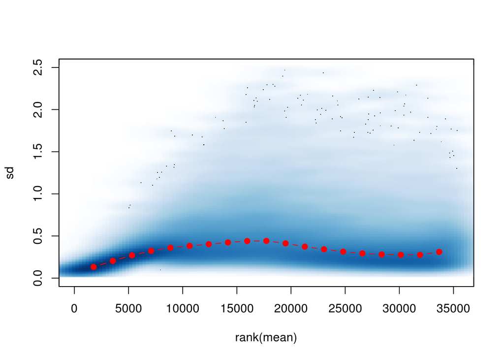

```r
meanSdPlot(assay(vsd)[rowSums(count.table)>0,], ylim = c(0,2.5))
```

As it is fairly linear, we can assume homoscedasticity. the slight initial trend / bump is due to genes having few counts in a few subset of the samples and hence having a higher variability. This is expected.

### 2.4.1 PCA analysis

We perform a Principal Component Analysis (PCA) of the data to do a quick quality assessment, *i.e.* replicate samples should cluster together and the first 2-3 dimensions should be explainable by biological means.

```r
pc <- prcomp(t(vst))
percent <- round(summary(pc)$importance[2,]*100)
smpls <- conditions
```

At first, we color the samples by date and sex

```r
sex.cols<-c("pink","lightblue")
sex.names<-c(F="Female",M="Male")
```

And check whether the observed separation is due to the sample sex

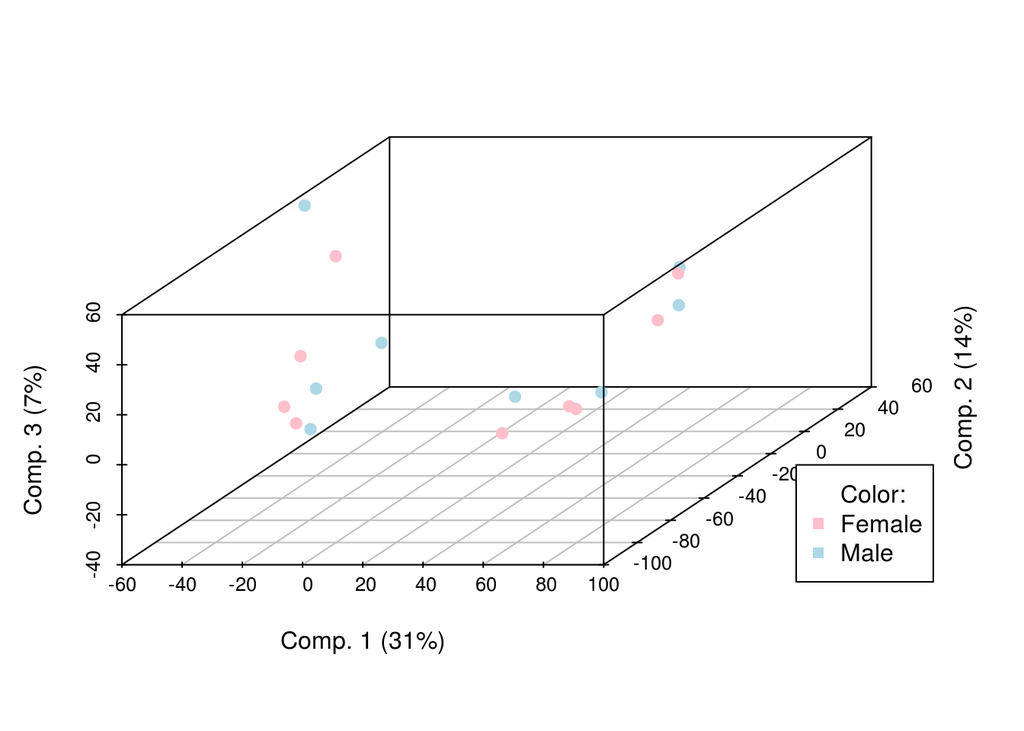

```r
scatterplot3d(pc$x[,1],
              pc$x[,2],
              pc$x[,3],
              xlab=paste("Comp. 1 (",percent[1],"%)",sep=""),
              ylab=paste("Comp. 2 (",percent[2],"%)",sep=""),
              zlab=paste("Comp. 3 (",percent[3],"%)",sep=""),
              color=sex.cols[as.integer(factor(sex))],
              pch=19)
legend("bottomright",pch=c(NA,15,15),col=c(NA,sex.cols[1:2]),
       legend=c("Color:",sex.names[levels(factor(sex))]))
```

```r
par(mar=mar)
```

This is obviously not the case at all. There are 2 clusters of points, but both contain pink and blue dots. So, we next color by sampling date

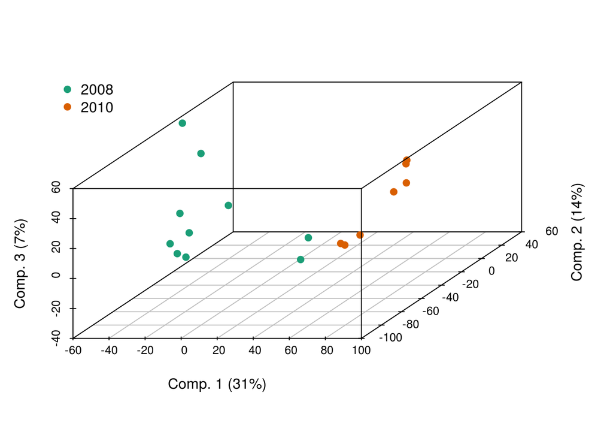

```r
dat <- date
scatterplot3d(pc$x[,1],
              pc$x[,2],
              pc$x[,3],
              xlab=paste("Comp. 1 (",percent[1],"%)",sep=""),
              ylab=paste("Comp. 2 (",percent[2],"%)",sep=""),
              zlab=paste("Comp. 3 (",percent[3],"%)",sep=""),
              color=pal[as.integer(factor(dat))],
              pch=19)
legend("topleft",pch=rep(c(19,23),each=10),col=rep(pal,2),legend=levels(factor(dat)),bty="n")
```

```r
par(mar=mar)
```

And here we **realise that the sampling date is a STRONG CONFOUNDING FACTOR** in our analysis. So let’s do a final plot with the color = sex and shape = date

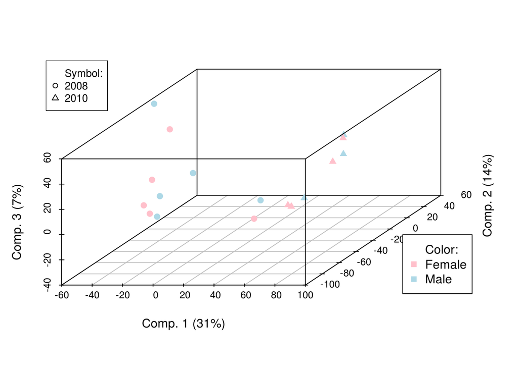

```r
scatterplot3d(pc$x[,1],
              pc$x[,2],
              pc$x[,3],
              xlab=paste("Comp. 1 (",percent[1],"%)",sep=""),
              ylab=paste("Comp. 2 (",percent[2],"%)",sep=""),
              zlab=paste("Comp. 3 (",percent[3],"%)",sep=""),
              color=sex.cols[as.integer(factor(sex))],
              pch=c(19,17)[as.integer(factor(dat))])
legend("bottomright",pch=c(NA,15,15),col=c(NA,sex.cols[1:2]),
       legend=c("Color:",sex.names[levels(factor(sex))]))
legend("topleft",pch=c(NA,21,24),col=c(NA,1,1),
       legend=c("Symbol:",levels(factor(dat))),cex=0.85)
```

```r
par(mar=mar)
```

Sometimes 3D PCA are not easy to interpret, so we may just as well look at 2 dimensions at a time.

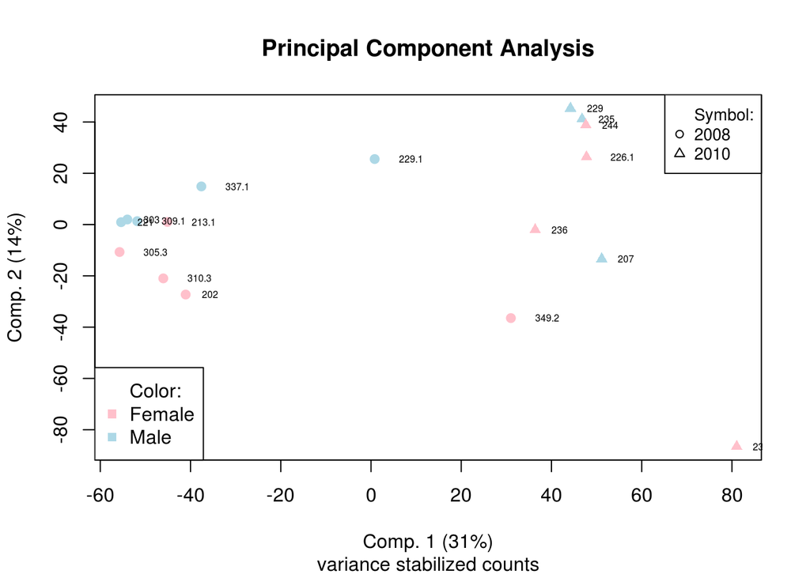

```r
plot(pc$x[,1],
     pc$x[,2],
     xlab=paste("Comp. 1 (",percent[1],"%)",sep=""),
     ylab=paste("Comp. 2 (",percent[2],"%)",sep=""),
     col=sex.cols[as.integer(factor(sex))],
     pch=c(19,17)[as.integer(factor(dat))],
     main="Principal Component Analysis",sub="variance stabilized counts")
legend("bottomleft",pch=c(NA,15,15),col=c(NA,sex.cols[1:2]),
       legend=c("Color:",sex.names[levels(factor(sex))]))
legend("topright",pch=c(NA,21,24),col=c(NA,1,1),
       legend=c("Symbol:",levels(factor(dat))),cex=0.85)
text(pc$x[,1],
     pc$x[,2],
     labels=conditions,cex=.5,adj=-1)
```

Clearly the sampling date separate most samples, *i.e.* first dimension equals “time”. It is interesting to see that the 2 samples sequenced deeper are in between the 2 clusters. We could hypothesize that the environmental change between sampling years are affecting a subset of genes, which expression levels are presumably lower; *i.e.* somewhat looking at transcriptional “noise” environmentaly-induced (difference in temperature, moisture,*etc.*). Since the 2 parent samples have been sequenced much deeper, the fact that they do not group with either cluster might be due to the fact that they, too, have an increased proportion of transcriptional “noise” possibly technically-induced; *i.e.* sequencing so deep that we start to measure non-mature mRNA, mis-splice mRNA, *etc.* - after all transcription has to be a stochastic process. Looking at the 2nd and 3rd dims does not reveal any obvious effects

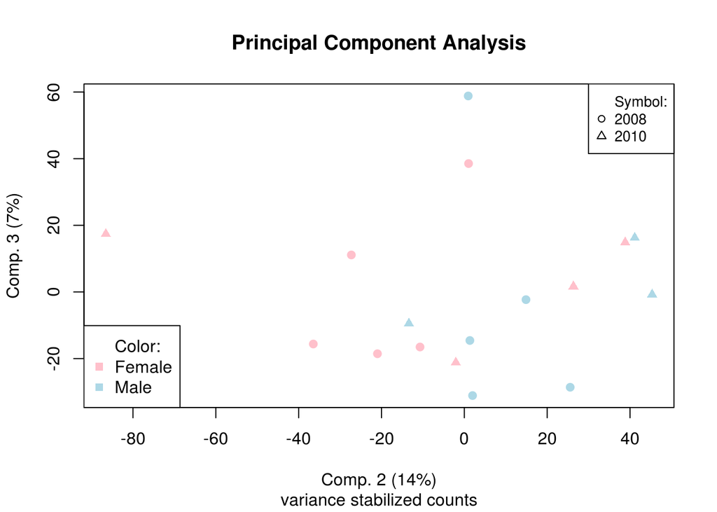

```r
plot(pc$x[,2],
     pc$x[,3],
     xlab=paste("Comp. 2 (",percent[2],"%)",sep=""),
     ylab=paste("Comp. 3 (",percent[3],"%)",sep=""),
     col=sex.cols[as.integer(factor(sex))],
     pch=c(19,17)[as.integer(factor(dat))],
     main="Principal Component Analysis",sub="variance stabilized counts")
legend("bottomleft",pch=c(NA,15,15),col=c(NA,sex.cols[1:2]),
       legend=c("Color:",sex.names[levels(factor(sex))]))
legend("topright",pch=c(NA,21,24),col=c(NA,1,1),
       legend=c("Symbol:",levels(factor(dat))),cex=0.85)
```

## 2.5 Doing the differential expression analysis.

The QA revealed that we have a confounding factor. Luckily, enough the grouping of sex is balanced between sampling years and hence we will be able to block the year effect to investigate the sex effect.

```r
yearSexDesign <- samples[grep("[2,3].*",samples$sample),c("sex","date")]
```

### 2.5.1 DESeq

The primary reason to use DESeq[Anders:2010p1659] over DESeq2 or edgeR[Robinson:2010p775] or any other is that DESeq is very conservative (see Soneson & Delorenzi (2013)). The second reason is that DESeq give less weight to outliers than DESeq2 does. Based on the study by Pakull *et al.* (2014), which identified a candidate gene: **Potri.019G047300** for sexual determination - the same we simultaneously, independantly originally identified in our analyses - it seems that our sample 226.1 may be mis-classified, so our first approach uses DESeq.

However, the sex phenotyping had been done thoroughly, so it may also be that the sex determination is a more complex trait and that Potri.019G047300 is only one factor influencing it

As introduced we want to look at the sex effect blocking for the year effect. We start by estimating the size factors and the dispersion

```r
cdsFull <- newCountDataSet(count.table,yearSexDesign)
cdsFull = estimateSizeFactors( cdsFull )
cdsFull = estimateDispersions( cdsFull )
```

We can now check the dispersion estimated by DESeq, which is, obviously, conservative. I.e. most dispersion values lie below the actual dispersion fit by about 1 fold.

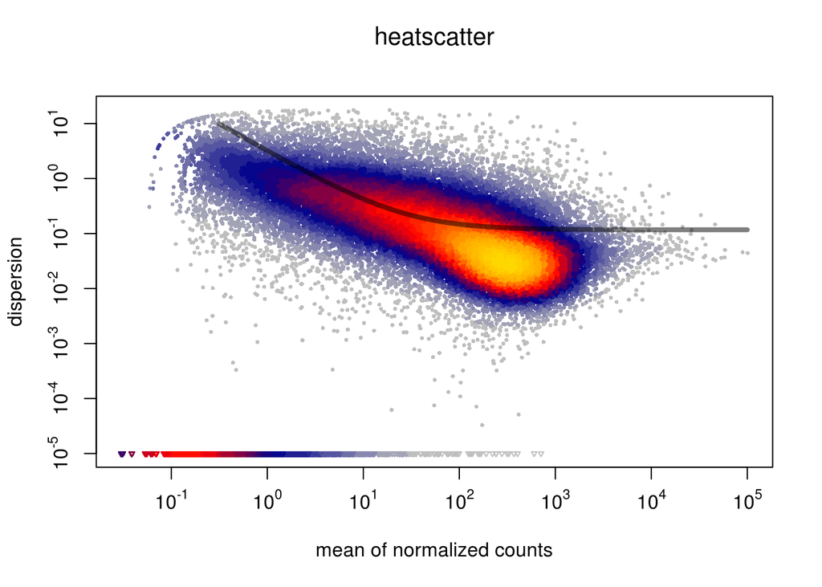

```r
plotDispLSD(cdsFull)
```

Next, we create both models (one considering the date only and one the date and sex combination)

```r
fit1 = suppressWarnings(fitNbinomGLMs( cdsFull, count ~ date + sex ))
```

```
## ...................................
```

```r
fit0 = suppressWarnings(fitNbinomGLMs( cdsFull, count ~ date))
```

```
## ...................................
```

For the rest of the analysis, we ignore the genes that did not converge in the previous step

```r
sel <- !is.na(fit1$converged) & !is.na(fit0$converged) & fit1$converged & fit0$converged
fit1 <- fit1[sel,]
fit0 <- fit0[sel,]
```

We calculate the GLM p-value and adjust them for multiple testing

```r
pvalsGLM = nbinomGLMTest( fit1, fit0 )
padjGLM = p.adjust( pvalsGLM, method="BH" )
```

Finally, we visualize the obtained results. A first insight shows that a number of genes have very high fold changes, which is due the fact that these genes have very few read in very few samples. For clarity, in the following plots, we filter those genes with a too high FC.

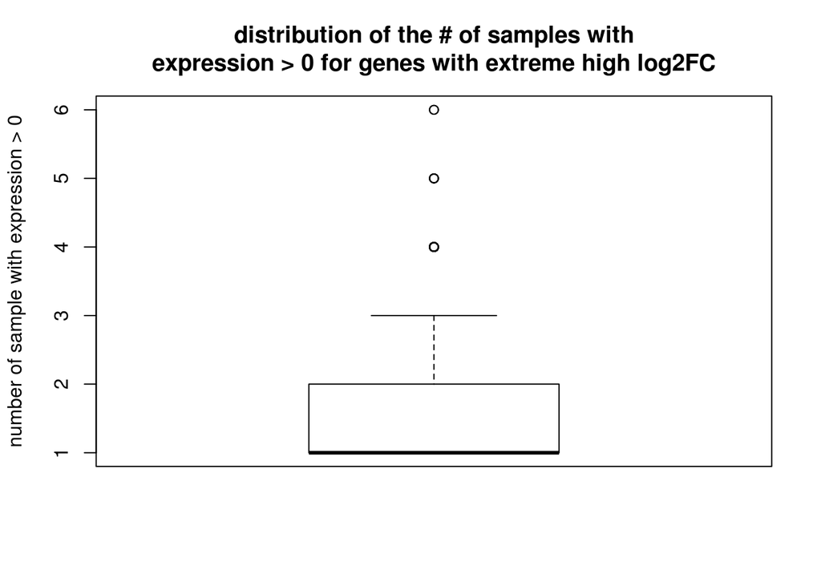

```r
boxplot(rowSums(count.table[rownames(fit1[fit1$sexM > 20,]),]>0),
        ylab="number of sample with expression > 0",
        main="distribution of the # of samples with\nexpression > 0 for genes with extreme high log2FC"
)
```

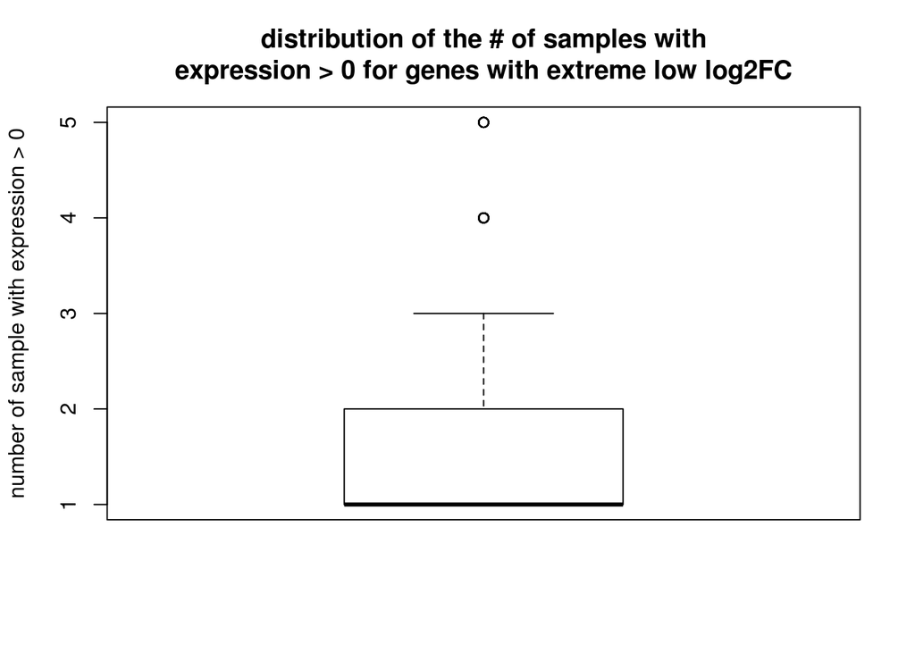

```r
boxplot(rowSums(count.table[rownames(fit1[fit1$sexM < -20,]),]>0),
        ylab="number of sample with expression > 0",
        main="distribution of the # of samples with\nexpression > 0 for genes with extreme low log2FC"
)
```

The vast majority of these genes are anyway not significant.

```r
range(padjGLM[fit1$sexM > 20])
```

```
## [1] 0.9999826 0.9999826
```

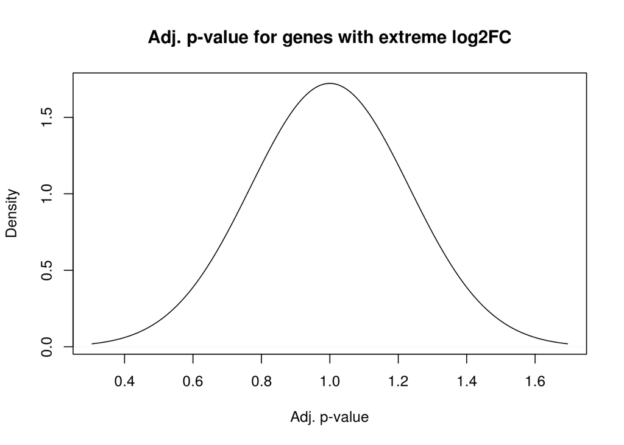

```r
plot(density(padjGLM[fit1$sexM > 20]),
     main="Adj. p-value for genes with extreme log2FC",
     xlab="Adj. p-value")
```

```r
range(padjGLM[fit1$sexM < -20])
```

```
## [1] 0.9079918 0.9999826
```

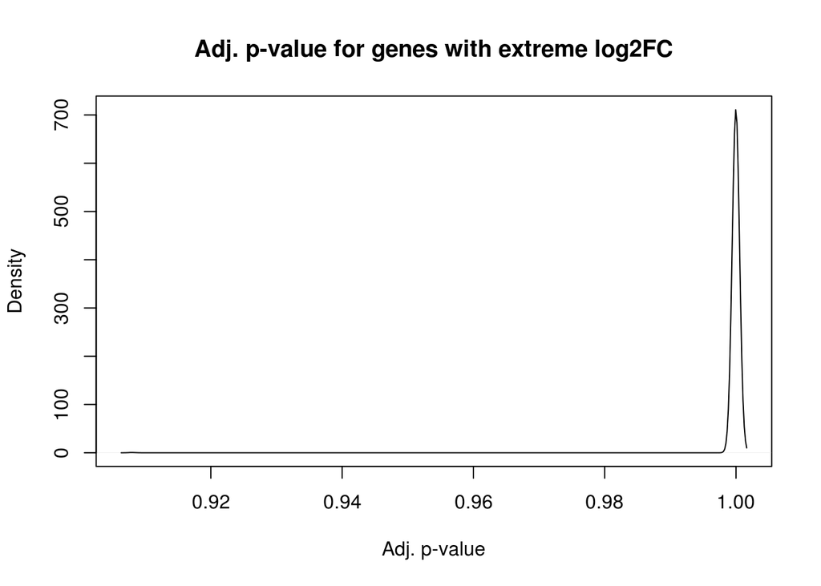

```r
plot(density(padjGLM[fit1$sexM < -20]),
     main="Adj. p-value for genes with extreme log2FC",
     xlab="Adj. p-value")
```

So we filter them out

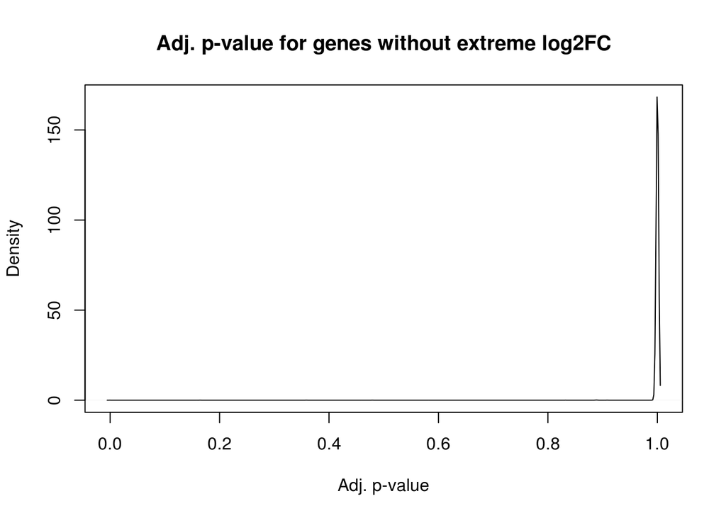

```r
sel <- fit1$sexM > -20 & fit1$sexM < 20
plot(density(padjGLM[sel]),
     main="Adj. p-value for genes without extreme log2FC",
     xlab="Adj. p-value")
```

```r
fit1 <- fit1[sel,]
padjGLM <- padjGLM[sel]
pvalsGLM <- pvalsGLM[sel]
```

A further look into the data reveals that two p-values are equal to 0. As this is inadequate for plotting log odds (-log of the p-value), we change these 0s to be 1 log10 fold change smaller than the otherwise smallest p-value (for plotting purposes only!)

```r
padjGLM[padjGLM==0] <- min(padjGLM[padjGLM!=0])/10
pvalsGLM[pvalsGLM==0] <- min(pvalsGLM[pvalsGLM!=0])/10
```

### 2.5.2 Visualize DESeq results

An intuitively easy to intrepret visualisation is the (volcanoplot)[http://en.wikipedia.org/wiki/Volcano_plot_(statistics)]. We plot both the non-adjusted and adjusted p-values to also visualise the multiple correction effect. First, the volcano plot with the non-adjusted p-values

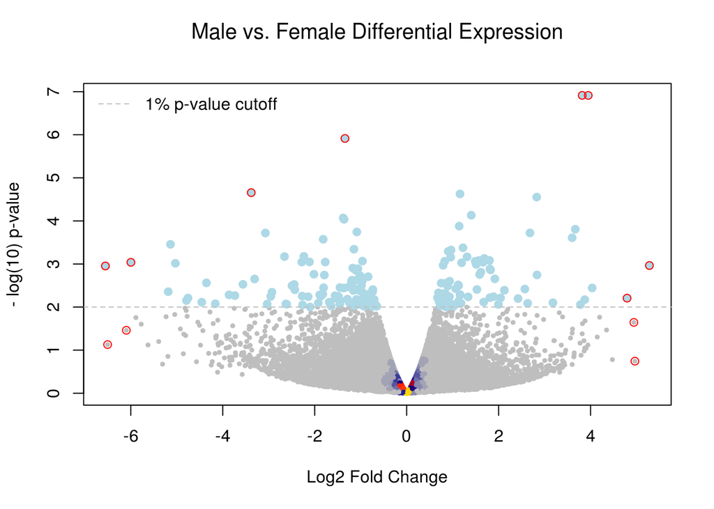

```r
heatscatter(fit1$sexM,-log10(pvalsGLM),
            main="Male vs. Female Differential Expression",cor=FALSE,
            xlab="Log2 Fold Change", ylab="- log(10) p-value")
legend("topleft",bty="n","1% p-value cutoff",lty=2,col="gray")
points(fit1[pvalsGLM<.01,"sexM"],-log10(pvalsGLM[pvalsGLM<.01]),col="lightblue",pch=19)
pos <- c(order(pvalsGLM)[1:4],order(fit1$sexM,decreasing=TRUE)[1:4],order(fit1$sexM)[1:4])
points(fit1[pos,"sexM"],-log10(pvalsGLM[pos]),col="red")
abline(h=2,lty=2,col="gray")
```

and then the volcano plot with the adjusted p-values

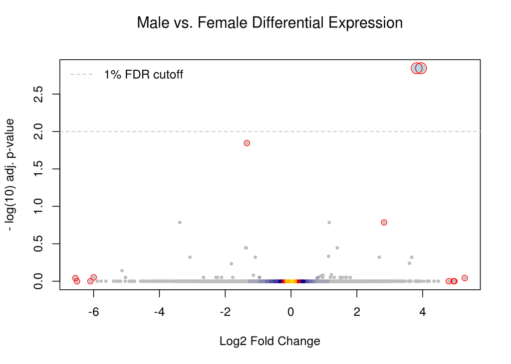

```r
heatscatter(fit1$sexM,-log10(padjGLM),
            main="Male vs. Female Differential Expression",cor=FALSE,
            xlab="Log2 Fold Change", ylab="- log(10) adj. p-value")
legend("topleft",bty="n","1% FDR cutoff",lty=2,col="gray")
points(fit1[padjGLM<.01,"sexM"],-log10(padjGLM[padjGLM<.01]),col="lightblue",pch=19,cex=1.5)
pos <- c(order(padjGLM)[1:4],order(fit1$sexM,decreasing=TRUE)[1:4],order(fit1$sexM)[1:4])
points(fit1[pos,"sexM"],-log10(padjGLM[pos]),col="red",cex=c(2,2,rep(1,length(pos)-2)))
abline(h=2,lty=2,col="gray")
```

As DESeq is an “older” implementation for this type of analysis, we redo the analysis using DESeq2. To ultimately be able to compare the obtained set of differential expression candidate genes, we save the list of genes significant at a 1% adjusted p-value cutoff.

```r
UmAspD <- rownames(fit1[padjGLM<.01,])
```

These are not so many

```r
UmAspD
```

```
## [1] "Potri.014G155300.0" "Potri.019G047300.0"
```

### 2.5.3 DESeq2 differential expression analyses

As you see, doing that type of analysis has been made more intuitive in DESeq2 (*i.e.* the same can be achieved in fewer commands).

```r
design(dds) <- ~date+sex
dds <- DESeq(dds)
```

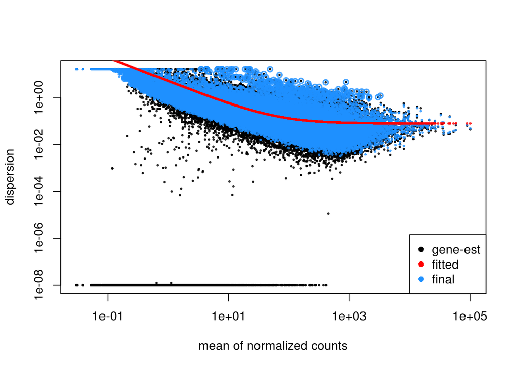

```r
plotDispEsts(dds)
```

```r
res <- results(dds,contrast=c("sex","F","M"))
```

In solely 4 commands we have reproduced the analysis and we have observed that the dispersion estimation looked different. DESeq2 introduces a so called “shrinkage”, which you can read more about in the DESeq2 [vignette](http://bioconductor.org/packages/release/bioc/vignettes/DESeq2/inst/doc/DESeq2.pdf). Next, we extract the results using the same 1% cutoff and plot similar validation plots

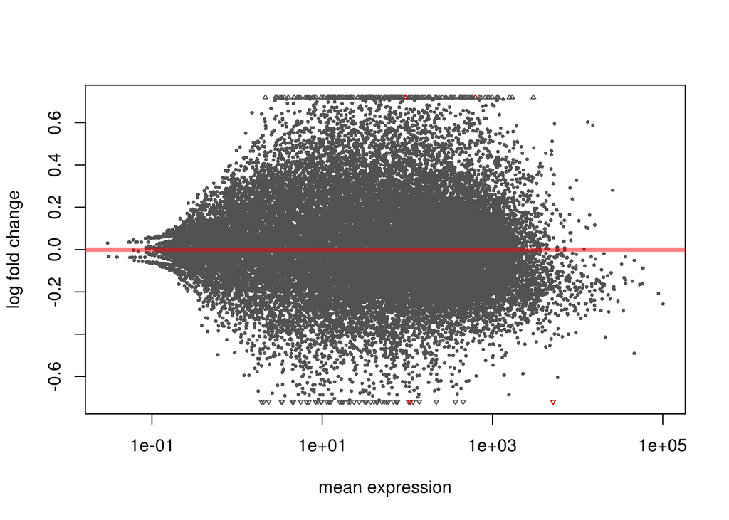

```r
alpha=0.01
plotMA(res,alpha=alpha)
```

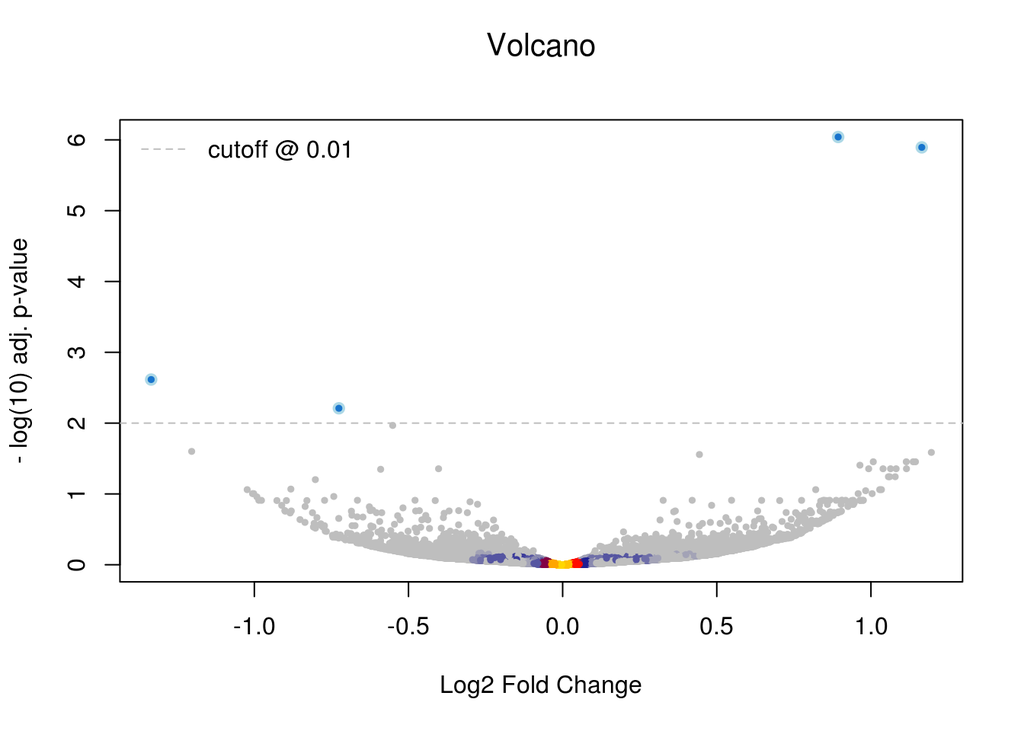

```r
volcanoPlot(res,alpha=alpha)
```

The volcano plot look similar to what we observed previously, although slightly less dead that in DESeq. We also do not get any genes with a p-value of 0

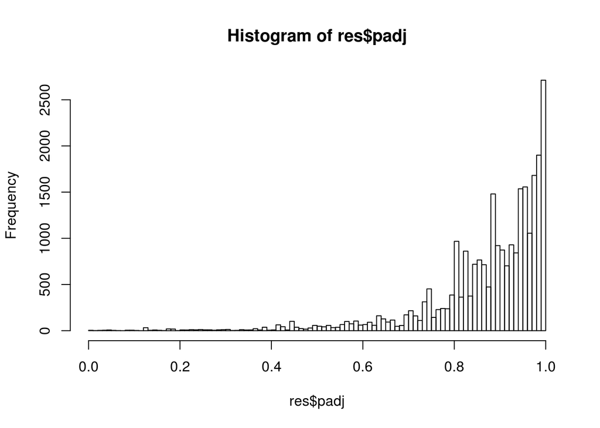

```r
hist(res$padj,breaks=seq(0,1,.01))
```

```r
sum(res$padj<alpha,na.rm=TRUE)
```

```
## [1] 4
```

4 genes are candidates for differential expression at a 1% adjusted p-value cutoff, which we also save for later comparison

```r
UmAspD2 <- rownames(res[order(res$padj,na.last=TRUE),][1:sum(res$padj<alpha,na.rm=TRUE),])
UmAspD2
```

```
## [1] "Potri.018G125000.0" "Potri.001G064500.0" "Potri.014G155300.0"
## [4] "Potri.011G140800.0"
```

```r
res["Potri.019G047300.0",]
```

```
## log2 fold change (MAP): sex F vs M
## Wald test p-value: sex F vs M
## DataFrame with 1 row and 6 columns
##                     baseMean log2FoldChange     lfcSE      stat
##                    <numeric>      <numeric> <numeric> <numeric>
## Potri.019G047300.0  50.16761     -0.8959982 0.2485006 -3.605618
##                          pvalue      padj
##                       <numeric> <numeric>
## Potri.019G047300.0 0.0003114105 0.1239994
```

```r
data.frame(
  counts=counts(dds,normalized=TRUE)["Potri.019G047300.0",],
  sex,
  date,
  conditions)
```

```
##         counts sex date conditions
## 1    1.2763452   F 2008        202
## 2   79.7469919   M 2010        207
## 3    1.1426981   F 2008      213.1
## 4   71.3869444   M 2008        221
## 5  100.7567673   F 2010      226.1
## 6  119.8101618   M 2008      229.1
## 7   95.7852731   M 2010        229
## 8   88.8696629   M 2010        235
## 9    3.6624808   F 2010        236
## 10   1.8788193   F 2010        239
## 11   2.2175894   F 2010        244
## 12  83.2846558   M 2008        303
## 13   3.0811417   F 2008      305.3
## 14  91.6210914   M 2008      309.1
## 15   0.0000000   F 2008      310.3
## 16 107.8163735   M 2008      337.1
## 17   0.5123541   F 2008      349.2
```

Nevertheless, while waiting for the next time the tree will flower and we can confirm its sex with certainty, we can assume that the sample was mis-sexed and see what effect a sex correction would have.

### 2.5.4 DESeq2 with the sample re-sexed

Given the data from Pakull *et al.* about that gene; assuming that the sample 226.1 was mis-sexed, we redo the DESeq2 analysis after swaping the sex of that sample

```r
sex[conditions=="226.1"] <- "M"
dds <- DESeqDataSetFromMatrix(
  countData = count.table,
  colData = data.frame(condition=conditions,
                       sex=sex,
                       date=date),
  design = ~ date+sex)
dds <- DESeq(dds)
```

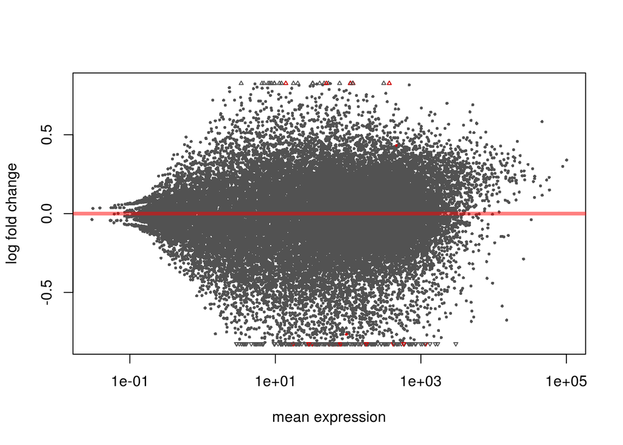

```r
res.swap <- results(dds,contrast=c("sex","M","F"))
plotMA(res.swap,alpha=alpha)
```

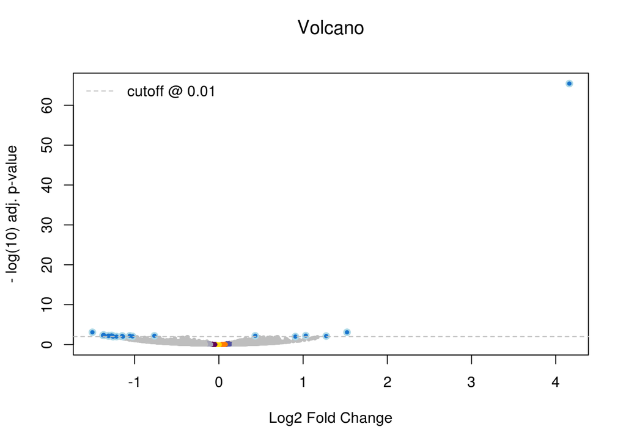

```r
volcanoPlot(res.swap,alpha=alpha)
```

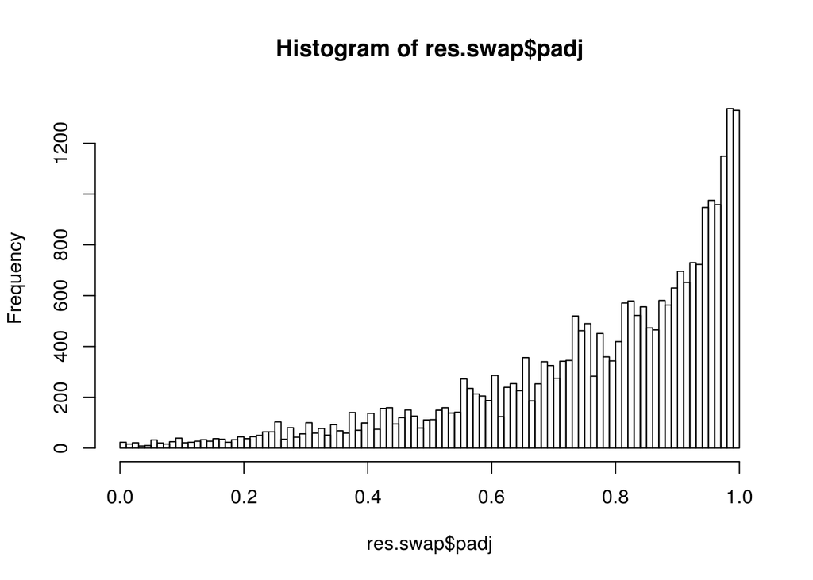

```r
hist(res.swap$padj,breaks=seq(0,1,.01))
```

```r
sum(res.swap$padj<alpha,na.rm=TRUE)
```

```
## [1] 23
```

```r
UmAspD2.swap <- rownames(res.swap[order(res.swap$padj,na.last=TRUE),][1:sum(res.swap$padj<alpha,na.rm=TRUE),])
UmAspD2.swap
```

```
##  [1] "Potri.019G047300.0" "Potri.014G155300.0" "Potri.019G124600.0"
##  [4] "Potri.009G142300.0" "Potri.014G055000.0" "Potri.017G122900.0"
##  [7] "Potri.T163500.0"    "Potri.007G125200.0" "Potri.019G121800.0"
## [10] "Potri.001G107600.0" "Potri.010G171400.0" "Potri.014G055400.0"
## [13] "Potri.018G125000.0" "Potri.001G402600.0" "Potri.012G028600.0"
## [16] "Potri.016G057600.0" "Potri.015G119800.0" "Potri.012G025400.0"
## [19] "Potri.001G102400.0" "Potri.006G171700.0" "Potri.007G125000.0"
## [22] "Potri.008G101500.0" "Potri.009G142000.0"
```

Fair enough, the gene Potri.019G047300.0 made it back in the list. But, still, to assess the importance of the 226.1 sample, we redo the DESeq2 DE analysis without it (since we have enough replicate for that removal not to affect the power of our analysis)

```r
sel <- conditions != "226.1"
dds <- DESeqDataSetFromMatrix(
  countData = count.table[,sel],
  colData = data.frame(condition=conditions[sel],
                       sex=sex[sel],
                       date=date[sel]),
  design = ~ date+sex)
dds <- DESeq(dds)
```

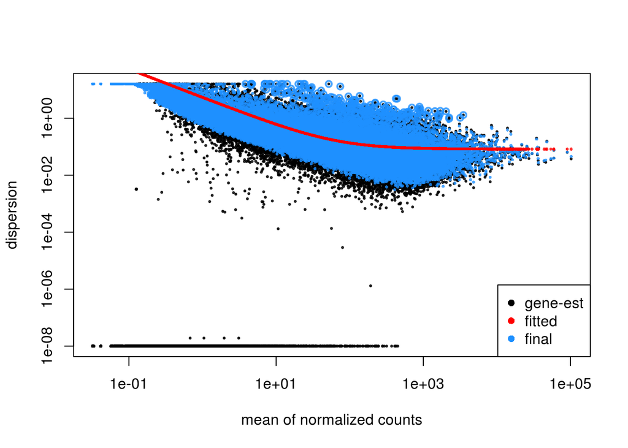

```r
plotDispEsts(dds)
```

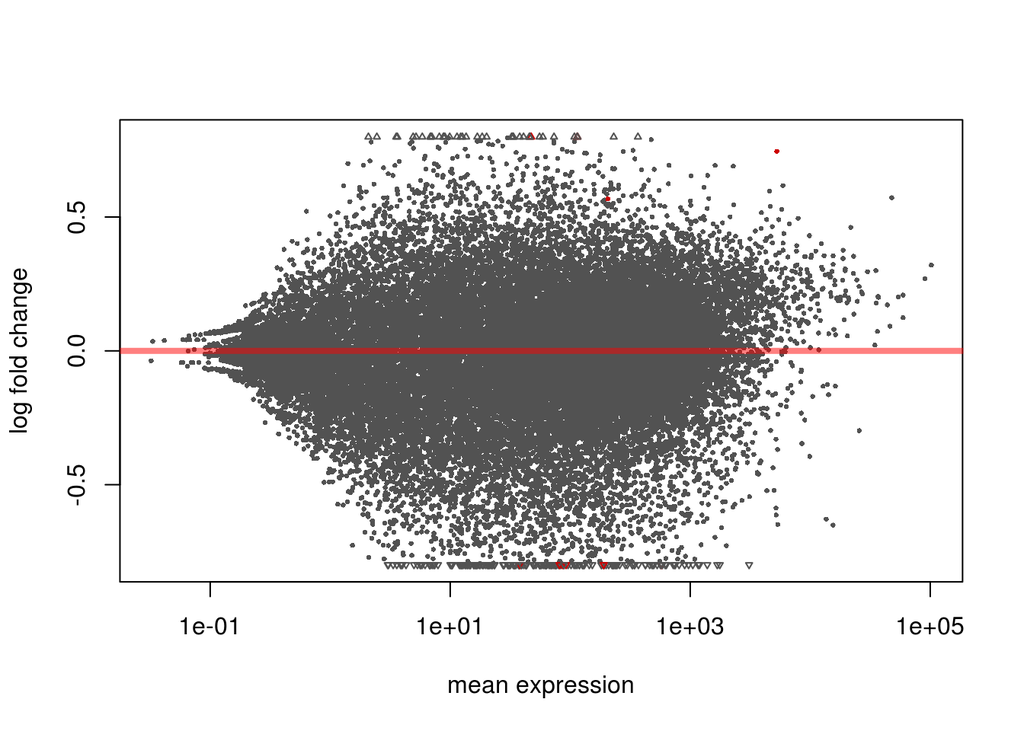

```r
res.sel <- results(dds,contrast=c("sex","M","F"))
plotMA(res.sel,alpha=alpha)
```

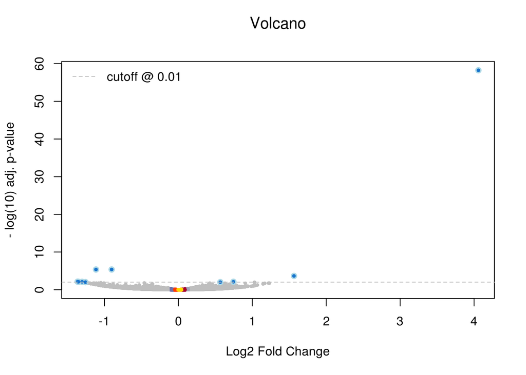

```r
volcanoPlot(res.sel,alpha=alpha)
```

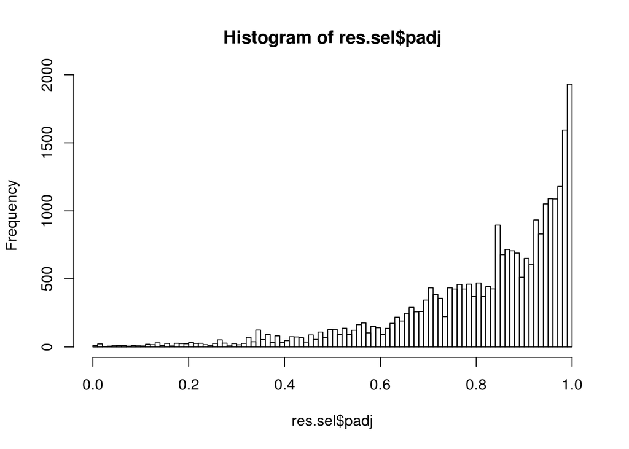

```r
hist(res.sel$padj,breaks=seq(0,1,.01))
```

```r
sum(res.sel$padj<alpha,na.rm=TRUE)
```

```
## [1] 10
```

```r
UmAspD2.sel <- rownames(res.sel[order(res.sel$padj,na.last=TRUE),][1:sum(res.sel$padj<alpha,na.rm=TRUE),])
UmAspD2.sel
```

```
##  [1] "Potri.019G047300.0" "Potri.001G064500.0" "Potri.018G125000.0"
##  [4] "Potri.014G155300.0" "Potri.019G124600.0" "Potri.011G140800.0"
##  [7] "Potri.017G122900.0" "Potri.009G142300.0" "Potri.T163500.0"
## [10] "Potri.014G129500.0"
```

## 2.6 Results comparison

We compare the results from the 4 approaches, the easiest way being to plot a [Venn Diagram](http://en.wikipedia.org/wiki/Venn_diagram)

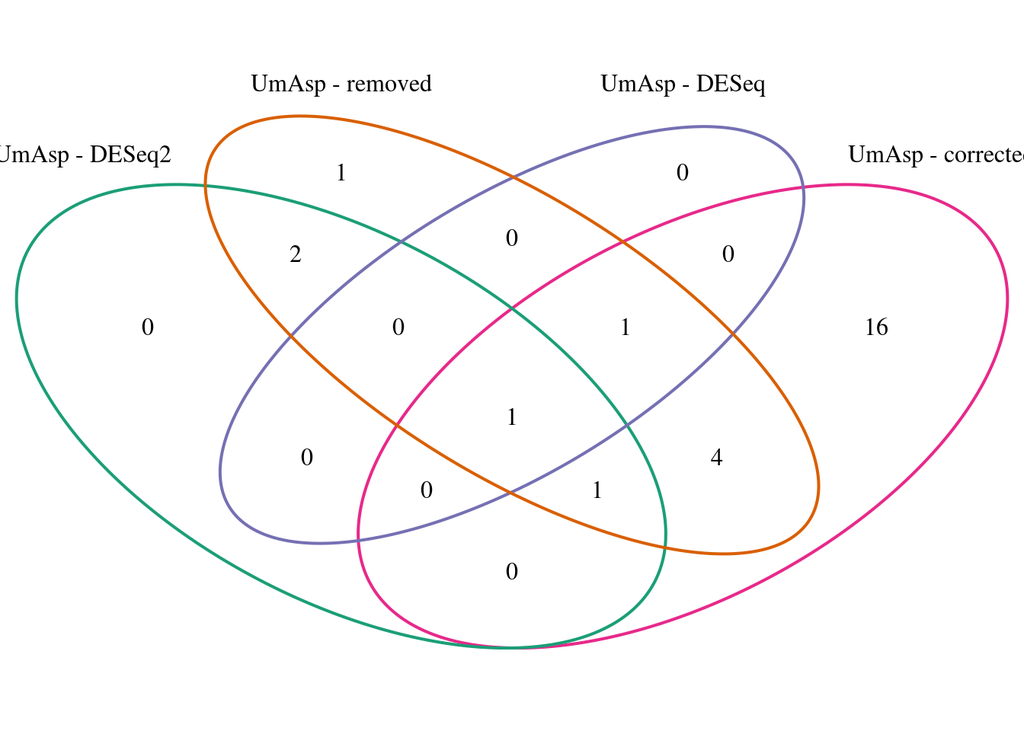

```r
plot.new()
grid.draw(venn.diagram(list(
  UmAsp=UmAspD2,
  UmAsp.swap=UmAspD2.swap,
  UmAsp.sel=UmAspD2.sel,
  UmAspD = UmAspD),
                       filename=NULL,
                       col=pal[1:4],
                       category.names=c("UmAsp - DESeq2",
                                        "UmAsp - corrected",
                                        "UmAsp - removed",
                                        "UmAsp - DESeq")))
```

Potri.014G155300.0 is constantly found by all 4 approaches Potri.019G047300.0 is found by DESeq and DESeq2, when the putative mis-sexed sample is removed or re-classified.

The sample sex correction actually leads to the identification of 16 genes unique to that comparison! It is unclear if these are the results of the technical error or if they would be worth investigating further.

```r
sort(intersect(UmAspD2,UmAspD))
```

```
## [1] "Potri.014G155300.0"
```

```r
sort(intersect(UmAspD2.swap,UmAspD))
```

```
## [1] "Potri.014G155300.0" "Potri.019G047300.0"
```

```r
sort(intersect(UmAspD2.sel,UmAspD))
```

```
## [1] "Potri.014G155300.0" "Potri.019G047300.0"
```

# 4 Appendix

Analyses performed when asking Mike Love (DESeq2 developer) why DESeq2 seem so sensitive to misclassification The short answer was to use the Cook distance to further investigate that and that the 1% FDR cutoff was conservative. These are commented out on purpose.

```r
## mis-classified
# sex <- samples$sex[match(colnames(count.table),samples$sample)]
# date <- factor(samples$date[match(colnames(count.table),samples$sample)])
# ddsM <- DESeqDataSetFromMatrix(
#   countData = count.table,
#   colData = data.frame(condition=conditions,
#                        sex=sex,
#                        date=date),
#   design = ~ date+sex)
# ddsM <- DESeq(ddsM)
# resM <- results(ddsM,contrast=c("sex","F","M"))
#
# counts(ddsM,normalized=TRUE)["Potri.019G047300.0",]
# resM["Potri.019G047300.0",]
# mcols(ddsM)[names(rowData(ddsM)) == "Potri.019G047300.0",]
#
# ## reclassified
# sexR <- sex
# sexR[5] <- "M"
# ddsR <- DESeqDataSetFromMatrix(
#   countData = count.table,
#   colData = data.frame(condition=conditions,
#                        sex=sexR,
#                        date=date),
#   design = ~ date+sex)
# ddsR <- DESeq(ddsR)
# resR <- results(ddsR,contrast=c("sex","F","M"))
#
# counts(ddsR,normalized=TRUE)["Potri.019G047300.0",]
# resR["Potri.019G047300.0",]
# mcols(ddsR)[names(rowData(ddsR)) == "Potri.019G047300.0",]
#
# ## samples details
# sex
# date
#
# ## the model is not be affected by the reclassification
# lapply(split(sex,date),table)
# lapply(split(sexR,date),table)
#
```

References

al, Robert C Gentleman et. 2004. “Bioconductor: open Software Development for Computational Biology and Bioinformatics.” *Genome Biology* 5 (10): R80.

Anders, Simon, Paul Pyl, and Wolfgang Huber. 2014. “HTSeq–A Python Framework to Work with High-Throughput Sequencing Data.” *Bioinformatics*.

B. Pakull, J. Lüneburg, B. Kersten, and M. Fladung. 2014. “A Simple PCR-Based Marker to Determine Sex in Aspen).” *Plant Biology*.

Delhomme, Nicolas, Kathryn Robinson, Niklas Mähler, Bastian Schiffthaler, Jenny Önskog, Benedicte Albrectsen, Pär Ingvarsson, Torgeir Hvidsten, Stefan Jansson, and Nathaniel Street. 2014. “Populus Tremula (European Aspen) Shows No Evidence of Sexual Dimorphism.” *BMC Plant Biology* 14 (1): 276–76. doi:10.1186/s12870-014-0276-5.

Love, Michael, Wolfgang Huber, and Simon Anders. 2014. “Moderated Estimation of Fold Change and Dispersion for RNA-Seq Data with DESeq2.” *Genome Biology*.

R Development Core Team. 2009. *R: A Language and Environment for Statistical Computing*. Vienna, Austria: R Foundation for Statistical Computing. http://www.R-project.org.

Soneson, Charlotte, and Mauro Delorenzi. 2013. “A Comparison of Methods for Differential Expression Analysis of RNA-Seq Data.” *BMC Bioinformatics* 14: 91. doi:10.1186/1471-2105-14-91.